# Lab 5 assignment - Point pattern analysis

```r
# Packages

rm(list=ls())

require(spatstat)
require(tidyverse)
require(terra)
require(rrapply)
```

# Challenge 1 (3 points)

Create a simulation window on a landscape stretching from 0 to 100 units in both the x and y directions. Now simulate the distribution of an organism on this landscape using a Poisson process with a lambda value of 0.01. Plot this organism’s distribution. How many organisms are there on your landscape? What is the expected number of organisms that you should find on this landscape based on your simulation parameters? Why?

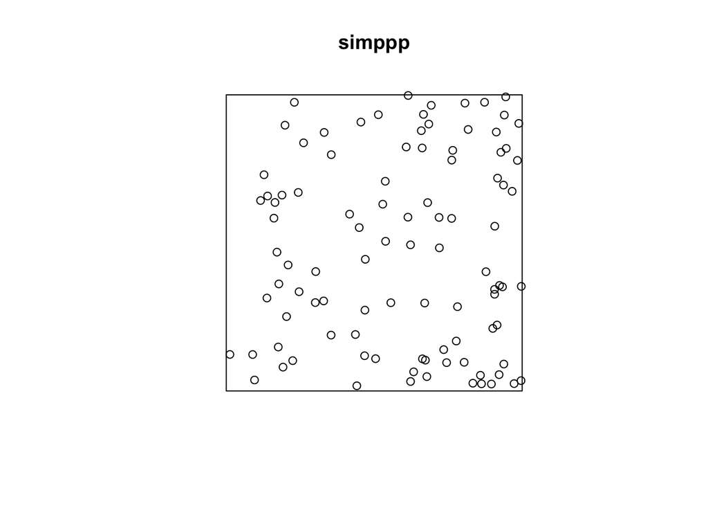

```r
# JNS seed

set.seed(73)

# Simulate some things

simWin <- owin(xrange=c(0,100), yrange=c(0,100))

simDist <- rpoispp(lambda = 0.01, lmax = NULL,  win = simWin, nsim = 1, drop = TRUE)

simppp = ppp(x=simDist$x, y=simDist$y, window = simWin)

plot(simppp)
```

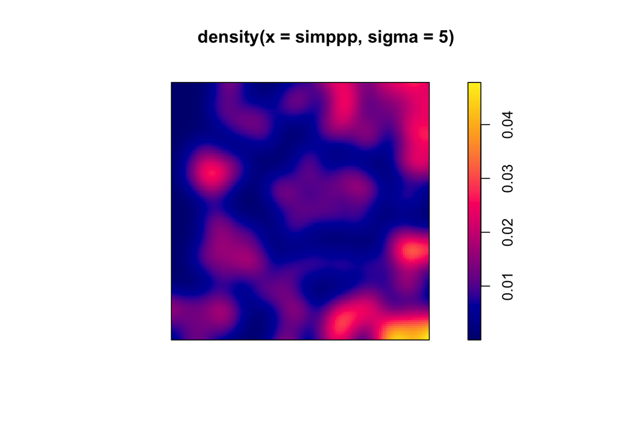

```r
plot(density(x = simppp, sigma = 5))
```

```r
# Playing around to make sure that I understand rpoispp

# 5 sims

set.seed(73)
simDist5 <- rpoispp(lambda = 0.01, lmax = NULL,  win = simWin, nsim = 5, drop = TRUE)
sd5 <- rrapply(simDist5, how = "bind")
mean(sd5$n)
```

```
## [1] 89.8
```

```r
# 10 sims

set.seed(73)
simDist10 <- rpoispp(lambda = 0.01, lmax = NULL,  win = simWin, nsim = 10, drop = TRUE)
sd10 <- rrapply(simDist10, how = "bind")
mean(sd10$n)
```

```
## [1] 94.1
```

```r
# 100 sims

set.seed(73)
simDist100 <- rpoispp(lambda = 0.01, lmax = NULL,  win = simWin, nsim = 100, drop = TRUE)
sd100 <- rrapply(simDist100, how = "bind")
mean(sd100$n)
```

```
## [1] 99.82
```

Place your answer to Challenge 1 here.

There are 98 organisms in my simulated landscape. I would have expected to have 100 organisms as there are 10,000 “units” in my landscape and at lambda = 0.01, each of those units have a 1% chance of containing an organism. However, since this is a single simulation, there is a chance that the actual number of organisms will not be 100 (as is the case here) because of random chance. Above, I played around with different numbers of simulations and the number of organisms gets progressively closer to 100 with increased numbers of simulations.

# Challenge 2 (3 points)

Verify that there no linear or quadratic pattern in the distribution of your organisms using fitted Poisson process models. Show the outcome of this analysis and explain your conclusion.

```r
# Models

ppInt = ppm(simppp, ~1)
ppXy = ppm(simppp, ~ x + y)
ppX2y = ppm(simppp, ~ poly(x,2) + y)
ppXy2 = ppm(simppp, ~ x + poly(y,2))
ppX2y2 = ppm(simppp, ~polynom (x, y, 2))

# AIC

data.frame(model = c('int', 'xy', 'x2y', 'xy2', 'x2y2'),
           AIC = c(AIC(ppInt), AIC(ppXy), AIC(ppX2y), AIC(ppXy2), AIC(ppX2y2)))
```

| model | AIC |
| --- | --- |
| int | 1104.573 |
| xy | 1097.619 |
| x2y | 1099.137 |
| xy2 | 1093.855 |
| x2y2 | 1097.196 |

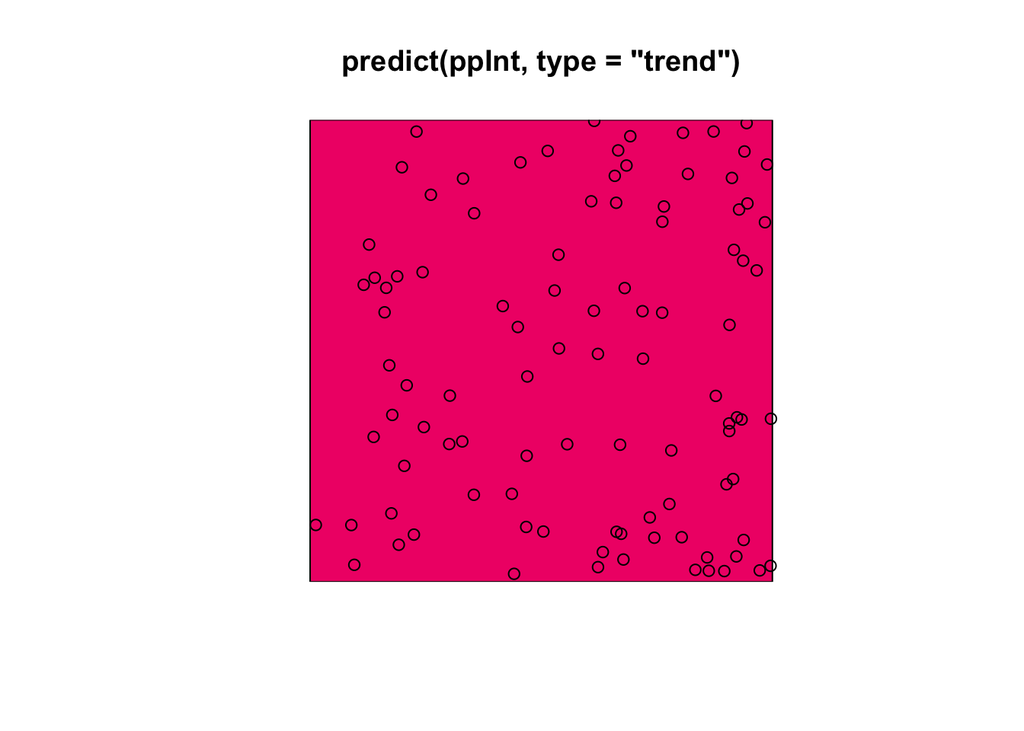

```r
# Plots in AIC order

plot(predict(ppInt, type='trend'))
plot(simppp, add=T)
```

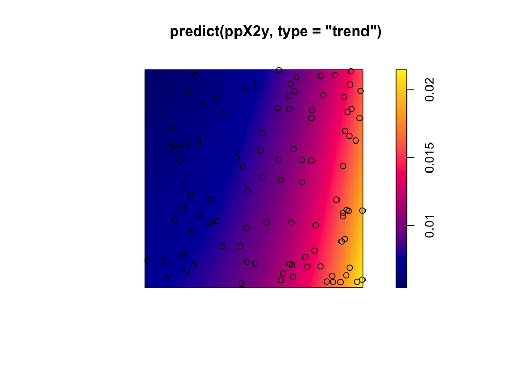

```r
plot(predict(ppX2y, type='trend'))
plot(simppp, add=T)
```

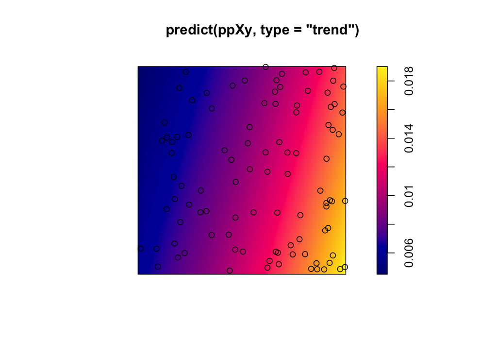

```r
plot(predict(ppXy, type='trend'))
plot(simppp, add=T)
```

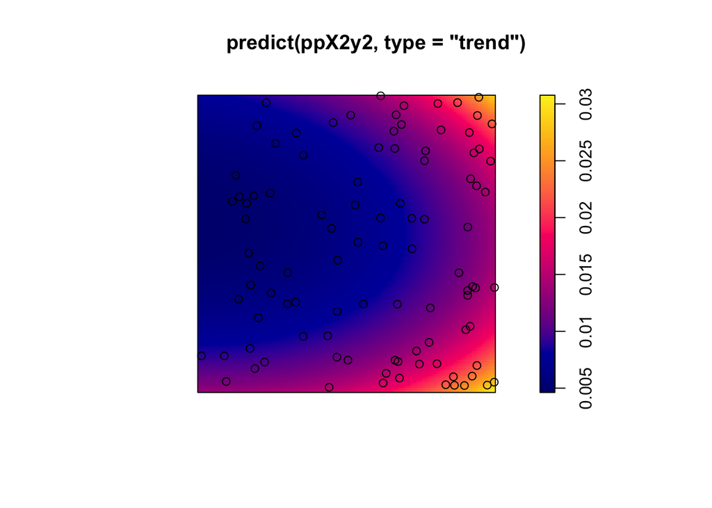

```r
plot(predict(ppX2y2, type='trend'))
plot(simppp, add=T)
```

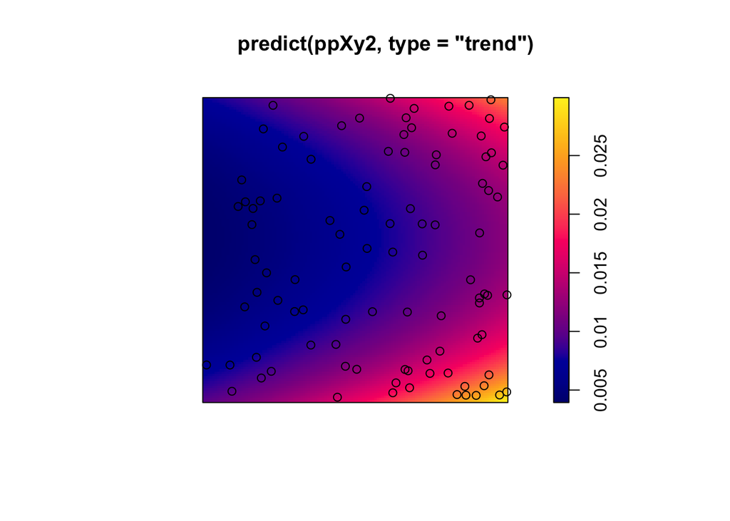

```r
plot(predict(ppXy2, type='trend'))
plot(simppp, add=T)
```

Place your answer to Challenge 2 here.

So, when I initially ran these models, AIC selected the quadratic model. However, I noticed that clusters in the upper and lower right corners were driving this pattern. I then created two additional models that allowed for only x or y to be quadratic. After adding these two additional models, AIC selected the model with a linear pattern on x and a quadratic pattern on y. Visually, this makes sense with the prediction plots. I think this sort of relationship could be possible if there was a “wedge” of lower quality habitat bisecting a patch of higher quality habitat. This would cause greater numbers of individuals to inhabit the higher quality habitat up to a certain number, then due to resource limitations or competition or some other threshold repulsion factor, some individuals would have to inhabit the lower quality habitat.

# Challenge 3 (14 points)

I have simulated the distributions of 2 critters and provided their x-y coordinates. One of them is a non-territorial predator. The second is a critter that is preyed upon by the predator and exhibits a fear response to the predator’s presence. Use the tools you learned in the lab to explore the distributions of these two critters. Identify which one is the predator and which is the prey, and provide code and a thorough justification supporting your conclusion.

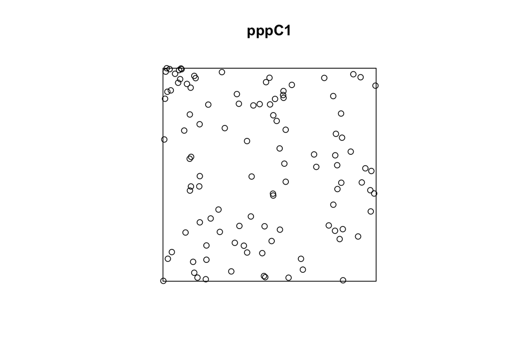

```r
# Supplied data

predPreyWin = owin(xrange = c(0, 100), yrange = c(0, 100))

critter1 = read.csv('https://raw.githubusercontent.com/ValenteJJ/SpatialEcology/main/Week5/species1.csv') %>%
  mutate(org = 'critter1')

critter2 = read.csv('https://raw.githubusercontent.com/ValenteJJ/SpatialEcology/main/Week5/species2.csv') %>%
  mutate(org = 'critter2')

# Lets make the point patterns and plot them

pppC1 = ppp(x=critter1$x, y=critter1$y, window = predPreyWin)

plot(pppC1)
```

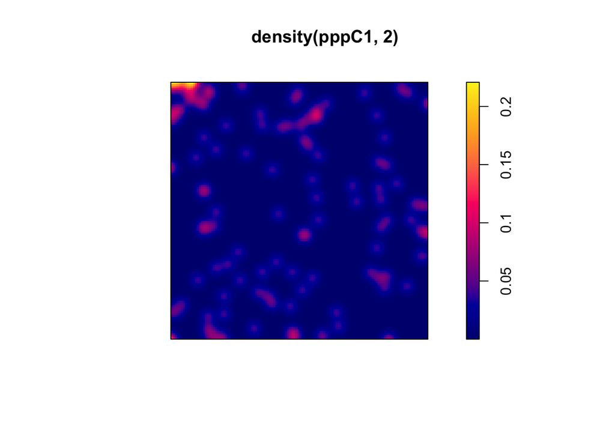

```r
plot(density(pppC1, 2))
```

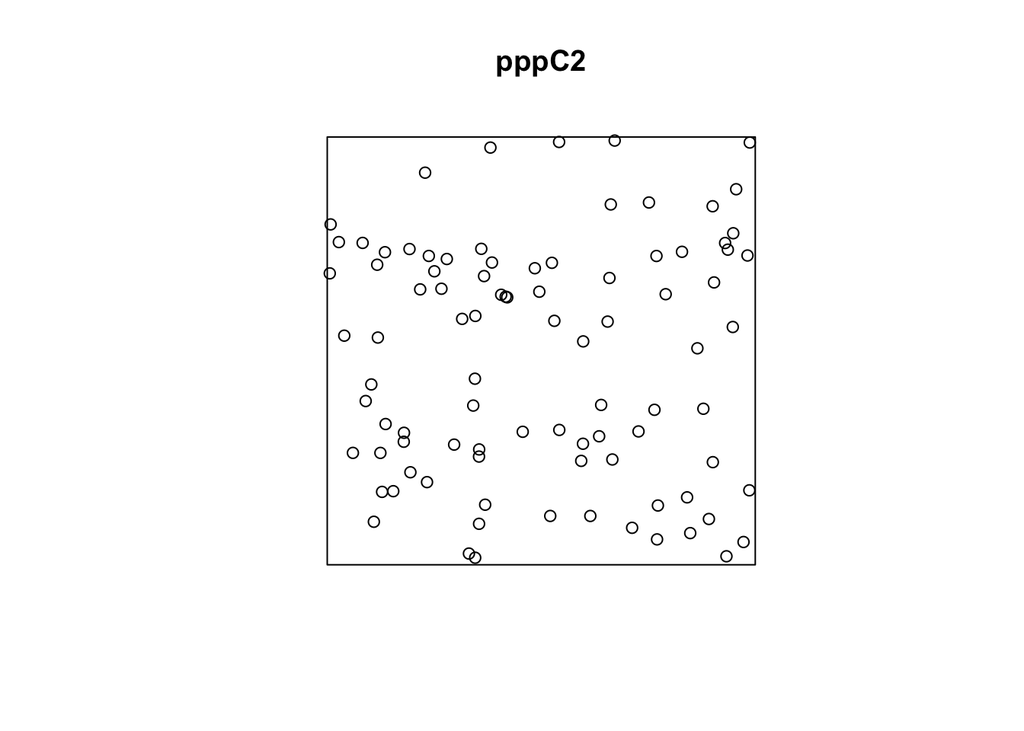

```r
pppC2 = ppp(x=critter2$x, y=critter2$y, window = predPreyWin)

plot(pppC2)
```

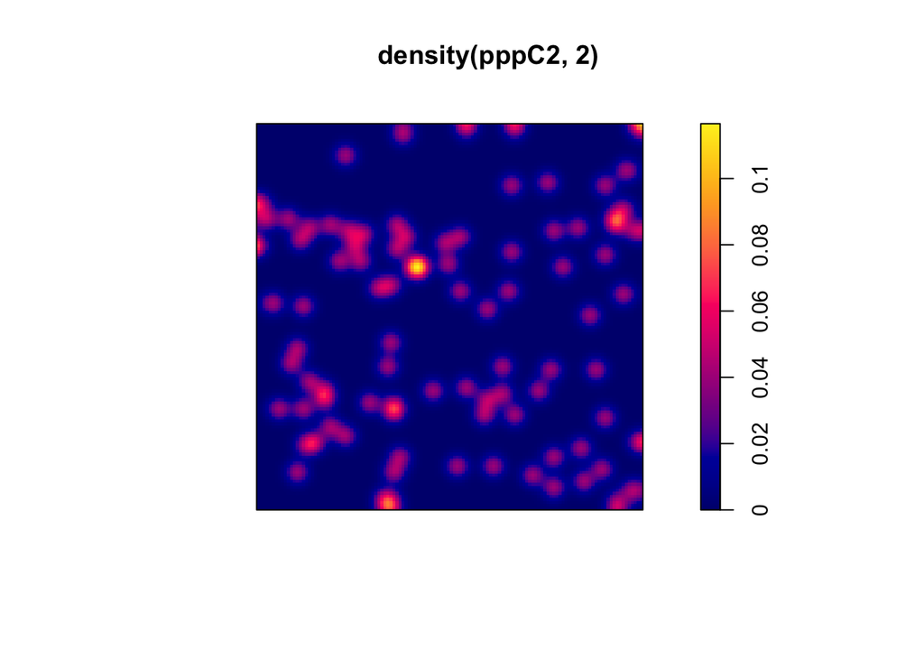

```r
plot(density(pppC2, 2))
```

Okay, based on the information given about the two critters, I can assume that the predator should display a more “random” distribution than the prey. I cannot tell who is who just yet, but visually, it certainly looks like one of them is more “bunched up” than the other… lets try some basic quadrat tests.

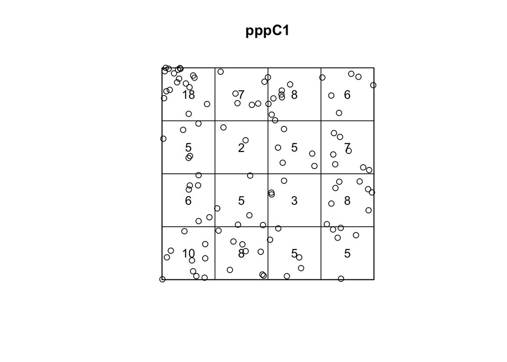

```r
# Critter 1 quadrat
q1 = quadratcount(pppC1, nx=4, ny=4)
plot(pppC1)
plot(q1, add=T)
```

```r
quadrat.test(pppC1, nx=4, ny=4, method='Chisq')
```

```
##
##  Chi-squared test of CSR using quadrat counts
##
## data:  pppC1
## X2 = 28.889, df = 15, p-value = 0.03325
## alternative hypothesis: two.sided
##
## Quadrats: 4 by 4 grid of tiles
```

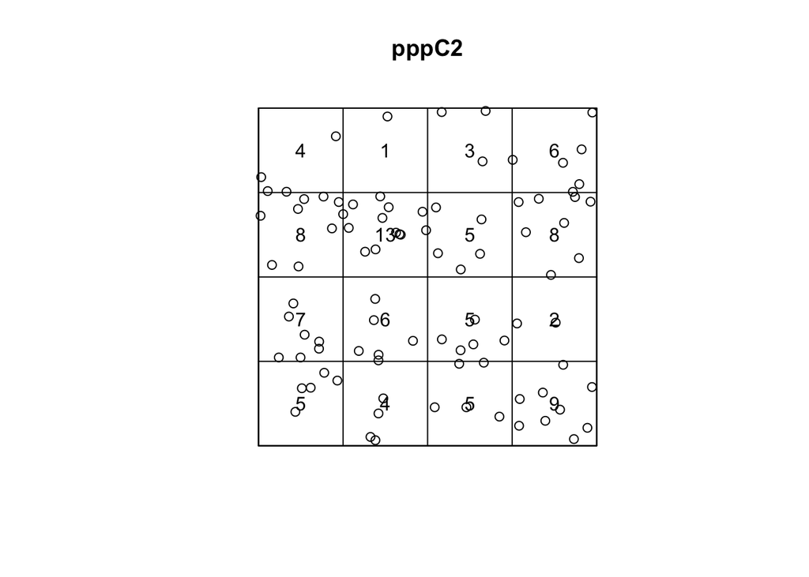

```r
# Critter 2 quadrat

q2 = quadratcount(pppC2, nx=4, ny=4)
plot(pppC2)
plot(q2, add=T)
```

```r
quadrat.test(pppC2, nx=4, ny=4, method='Chisq')
```

```
##
##  Chi-squared test of CSR using quadrat counts
##
## data:  pppC2
## X2 = 22.407, df = 15, p-value = 0.1952
## alternative hypothesis: two.sided
##
## Quadrats: 4 by 4 grid of tiles
```

Hmm… one of the two critters confirms to CSR and the other does not. That definitely seems like a clue. Lets look at L values for each.

```r
# Critter 1
lCsr1 = envelope(pppC1, Lest, nsim=99, rank=1, correction = "best", global=F)
```

```
## Generating 99 simulations of CSR  ...
## 1, 2, 3, 4, 5, 6, 7, 8, 9, 10, 11, 12, 13, 14, 15, 16, 17, 18, 19, 20,
## 21, 22, 23, 24, 25, 26, 27, 28, 29, 30, 31, 32, 33, 34, 35, 36, 37, 38, 39, 40,
## 41, 42, 43, 44, 45, 46, 47, 48, 49, 50, 51, 52, 53, 54, 55, 56, 57, 58, 59, 60,
## 61, 62, 63, 64, 65, 66, 67, 68, 69, 70, 71, 72, 73, 74, 75, 76, 77, 78, 79, 80,
## 81, 82, 83, 84, 85, 86, 87, 88, 89, 90, 91, 92, 93, 94, 95, 96, 97, 98,
## 99.
##
## Done.
```

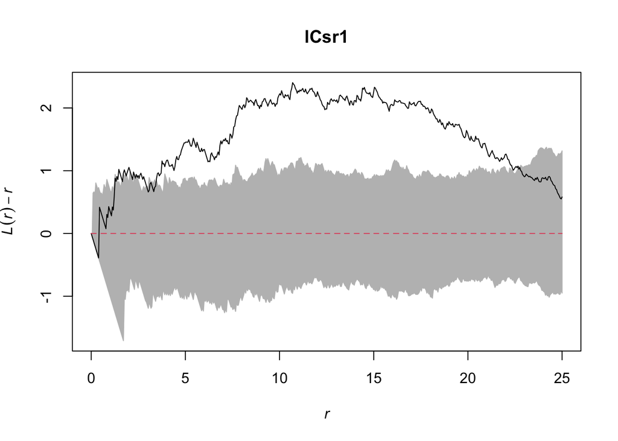

```r
plot(lCsr1, .-r~r, shade=c('hi', 'lo'), legend=F)
```

```r
# Critter 2

lCsr2 = envelope(pppC2, Lest, nsim=99, rank=1, correction= "best", global=F)
```

```
## Generating 99 simulations of CSR  ...
## 1, 2, 3, 4, 5, 6, 7, 8, 9, 10, 11, 12, 13, 14, 15, 16, 17, 18, 19, 20,
## 21, 22, 23, 24, 25, 26, 27, 28, 29, 30, 31, 32, 33, 34, 35, 36, 37, 38, 39, 40,
## 41, 42, 43, 44, 45, 46, 47, 48, 49, 50, 51, 52, 53, 54, 55, 56, 57, 58, 59, 60,
## 61, 62, 63, 64, 65, 66, 67, 68, 69, 70, 71, 72, 73, 74, 75, 76, 77, 78, 79, 80,
## 81, 82, 83, 84, 85, 86, 87, 88, 89, 90, 91, 92, 93, 94, 95, 96, 97, 98,
## 99.
##
## Done.
```

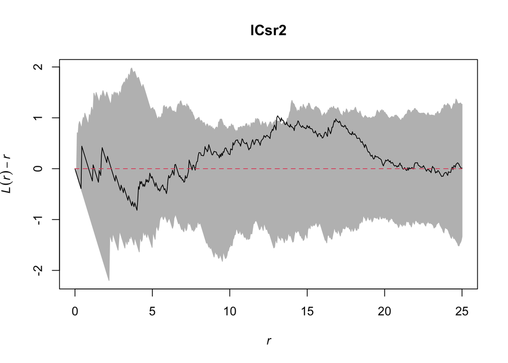

```r
plot(lCsr2, .-r~r, shade=c('hi', 'lo'), legend=F)
```

Once again, one of the critters is way outside of the upper and lower envelope. The evidence is pretty compelling so far, but lets try and look at L values accounting for the distribution of the other and itself…

```r
# Combine them

tmp = data.frame(x = c(critter1$x, critter2$x), y = c(critter1$y, critter2$y), org = c(critter1$org, critter2$org))

# Make, split, and plot point pattern

pppPa = ppp(tmp$x, tmp$y, window = predPreyWin, marks = as.factor(tmp$org))

split(pppPa)
```

```
## Point pattern split by factor
##
## critter1:
## Planar point pattern: 108 points
## window: rectangle = [0, 100] x [0, 100] units
##
## critter2:
## Planar point pattern: 91 points
## window: rectangle = [0, 100] x [0, 100] units
```

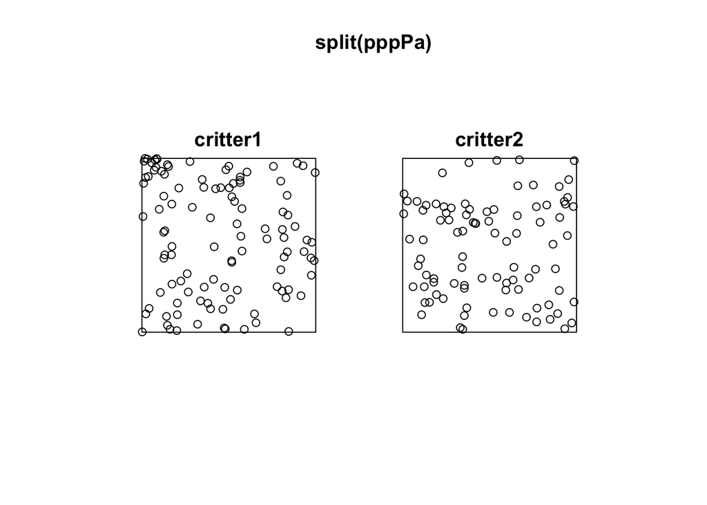

```r
plot(split(pppPa))
```

```r
# Lcross

lcrossC12 = envelope(pppPa, Lcross, nsim=99, rank=1, i = "critter1", j = "critter2", global=F, simulate = expression(rlabel(pppPa)))
```

```
## Generating 99 simulations by evaluating expression  ...
## 1, 2, 3, 4, 5, 6, 7, 8, 9, 10, 11, 12, 13, 14, 15, 16, 17, 18, 19, 20,
## 21, 22, 23, 24, 25, 26, 27, 28, 29, 30, 31, 32, 33, 34, 35, 36, 37, 38, 39, 40,
## 41, 42, 43, 44, 45, 46, 47, 48, 49, 50, 51, 52, 53, 54, 55, 56, 57, 58, 59, 60,
## 61, 62, 63, 64, 65, 66, 67, 68, 69, 70, 71, 72, 73, 74, 75, 76, 77, 78, 79, 80,
## 81, 82, 83, 84, 85, 86, 87, 88, 89, 90, 91, 92, 93, 94, 95, 96, 97, 98,
## 99.
##
## Done.
```

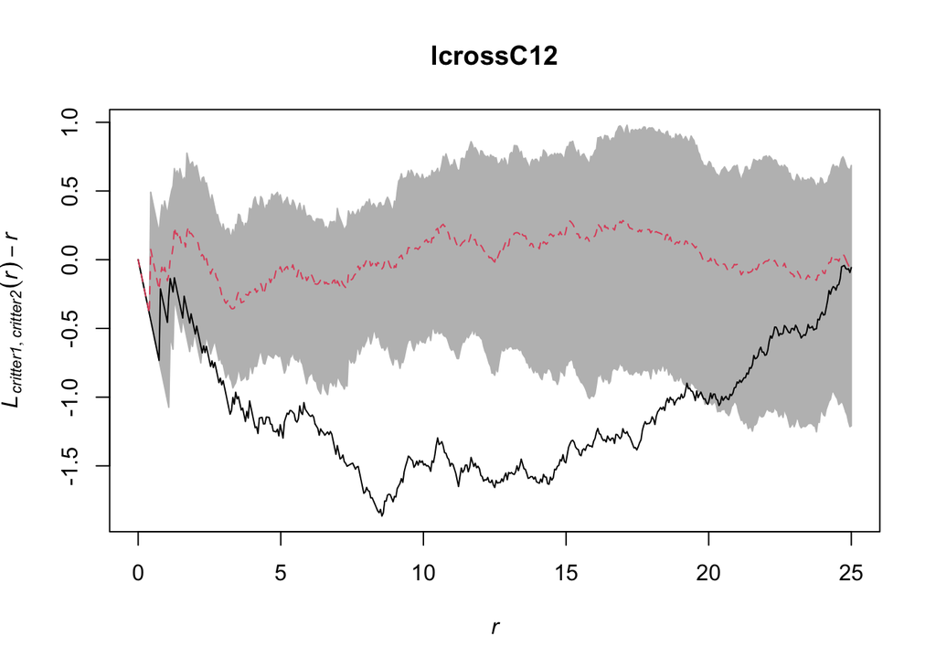

```r
plot(lcrossC12, .-r~r, legend=F) # Less than expected by envelope
```

```r
lcrossC11 = envelope(pppPa, Lcross, nsim=99, rank=1, i = "critter1", j = "critter1", global=F, simulate = expression(rlabel(pppPa)))
```

```
## Generating 99 simulations by evaluating expression  ...
## 1, 2, 3, 4, 5, 6, 7, 8, 9, 10, 11, 12, 13, 14, 15, 16, 17, 18, 19, 20,
## 21, 22, 23, 24, 25, 26, 27, 28, 29, 30, 31, 32, 33, 34, 35, 36, 37, 38, 39, 40,
## 41, 42, 43, 44, 45, 46, 47, 48, 49, 50, 51, 52, 53, 54, 55, 56, 57, 58, 59, 60,
## 61, 62, 63, 64, 65, 66, 67, 68, 69, 70, 71, 72, 73, 74, 75, 76, 77, 78, 79, 80,
## 81, 82, 83, 84, 85, 86, 87, 88, 89, 90, 91, 92, 93, 94, 95, 96, 97, 98,
## 99.
##
## Done.
```

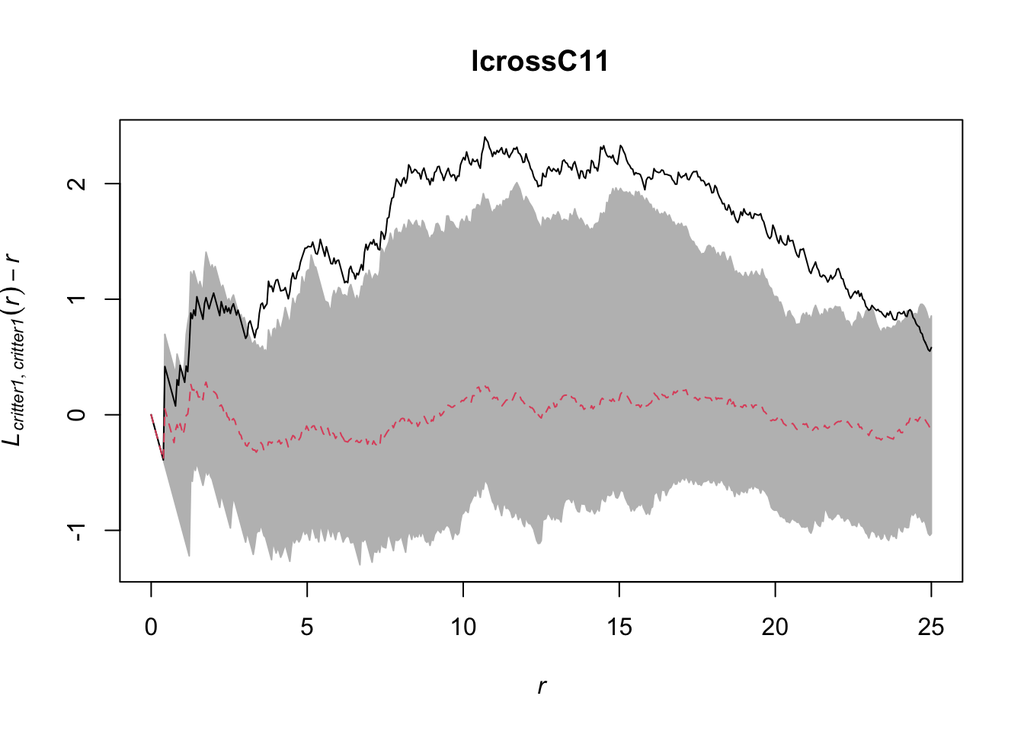

```r
plot(lcrossC11, .-r~r, legend=F) # More then expected by envelope
```

```r
lcrossC22 = envelope(pppPa, Lcross, nsim=99, rank=1, i = "critter2", j = "critter2", global=F, simulate = expression(rlabel(pppPa)))
```

```
## Generating 99 simulations by evaluating expression  ...
## 1, 2, 3, 4, 5, 6, 7, 8, 9, 10, 11, 12, 13, 14, 15, 16, 17, 18, 19, 20,
## 21, 22, 23, 24, 25, 26, 27, 28, 29, 30, 31, 32, 33, 34, 35, 36, 37, 38, 39, 40,
## 41, 42, 43, 44, 45, 46, 47, 48, 49, 50, 51, 52, 53, 54, 55, 56, 57, 58, 59, 60,
## 61, 62, 63, 64, 65, 66, 67, 68, 69, 70, 71, 72, 73, 74, 75, 76, 77, 78, 79, 80,
## 81, 82, 83, 84, 85, 86, 87, 88, 89, 90, 91, 92, 93, 94, 95, 96, 97, 98,
## 99.
##
## Done.
```

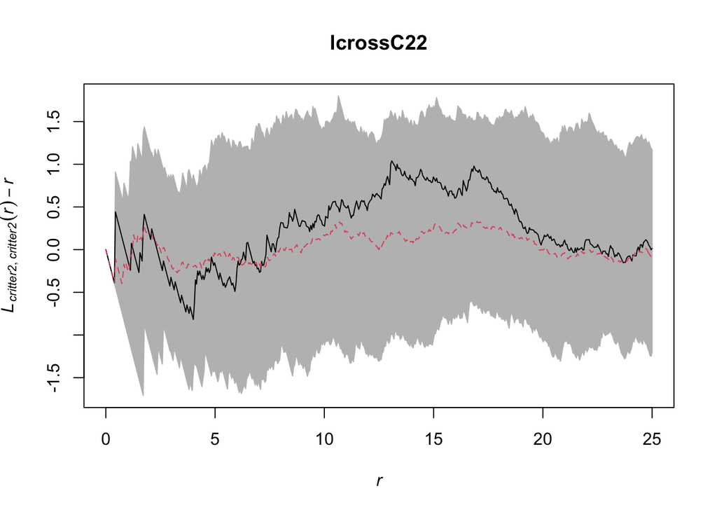

```r
plot(lcrossC22, .-r~r, legend=F) # Within envelope
```